# Spam detection example

Matt Taddy

Itamar Caspi

2019-10-19

Abstract

A replication of the spam detection example that appear in Matt Taddy’s “Business Data Science”, Chapter 2 under “Logistic Regression.”

## Setup

Load required packages

```r
if (!require("pacman")) install.packages("pacman")

pacman::p_load(here,       # for referencing files and folders
               tidyverse,  # for data reading wrangling and visualization
               tidymodels) # for data modeling
```

Read the spam dataset

```r
email <- read_csv(here("spam", "spam.csv"))
```

## Estimate the full model

we fit the full model (you don’t need to worry about the warning. It says that some covariates are nearly perfect predictors.)

```r
spammy <- glm(spam ~ ., data=email, family='binomial')
```

The guy is named George and he works in a cs dept

```r
email %>%
  group_by(spam, word_george, word_free) %>%
  tally() %>%
  pivot_wider(names_from = spam, values_from = n)
```

```
## # A tibble: 4 x 4
## # Groups:   word_george [2]
##   word_george word_free   `0`   `1`
##         <dbl>     <dbl> <int> <int>
## 1           0         0  1816   816
## 2           0         1   200   989
## 3           1         0   720     8
## 4           1         1    52    NA
```

The model’s coefficients

```r
spammy %>%
  tidy() %>%
  filter(term %in% c("word_george", "word_free")) %>%
  mutate(exp_estimate = exp(estimate),
         invexp_estimate = 1/exp(estimate)) %>%
  select(term, exp_estimate, invexp_estimate)
```

```
## # A tibble: 2 x 3
##   term        exp_estimate invexp_estimate
##   <chr>              <dbl>           <dbl>
## 1 word_free        4.68              0.214
## 2 word_george      0.00309         324.
```

Predict spam versus not-spam probabilities and odds-ratio for two arbitrary observations (the 1st and 4000th)

```r
# odds
spammy %>%
  augment() %>%
  select(.fitted) %>%
  slice(1,4000)
```

```
## # A tibble: 2 x 1
##   .fitted
##     <dbl>
## 1    2.03
## 2   -1.73
```

```r
# probability
spammy %>%
  augment(type.predict = "response") %>%
  select(.fitted) %>%
  slice(1,4000)
```

```
## # A tibble: 2 x 1
##   .fitted
##     <dbl>
## 1   0.884
## 2   0.151
```

Plot fitted values (probabilities) vs actual

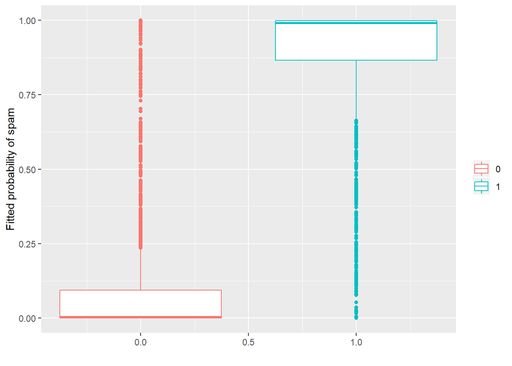

```r
spammy %>%
  augment(type.predict = "response") %>%
  ggplot(aes(x = spam, y = .fitted, color = factor(spam))) +
  geom_boxplot() +
  labs(x = "",
       y = "Fitted probability of spam",
       color = "")
```

## Out-of-sample prediction

Split the data in two. One data set, called the training set, and the other, the test set. We do so, by using the `initial_split()`, `training()`, and `testing()` functions from the `rsampl` package:

```r
set.seed(1234) # for the replicating the results

email_split <- email %>%
  initial_split(prop = 0.7825) # the prop is set to make the size of the test set = 1000

email_split
```

```
## <3601/1000/4601>
```

```r
email_training <- email_split %>% training()
email_testing  <- email_split %>% testing()
```

Estimate our model using the training set

```r
spamtrain <- glm(spam ~ ., data=email_training, family='binomial')
```

Use the `spamtrain` model to make predictions on the test dataset

```r
spampredict <- spamtrain %>%
  augment(newdata = email_testing,
          type.predict = "response")
```

Plot predicted values (probabilities) vs actual

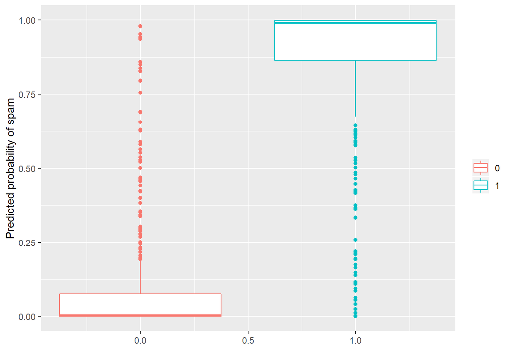

```r
spampredict %>%
  ggplot(aes(x = spam, y = .fitted, color = factor(spam))) +
  geom_boxplot() +
  labs(x = "",
       y = "Predicted probability of spam",
       color = "")
```

## Deviance

In-sample proportion of variance explained ($R^2$)

```r
glance(spammy) %>%
  mutate(R2 = (1 - deviance / null.deviance)) %>%
  select(null.deviance, deviance, R2)
```

```
## # A tibble: 1 x 3
##   null.deviance deviance    R2
##           <dbl>    <dbl> <dbl>
## 1         6170.    1549. 0.749
```

Out-of-sample $R^2$

```r
# This function returns the log loss for a single prediction
log_loss <- function(actual, pred) {
  loss <- -2 * (actual * log(pred) + (1 - actual) * log(1 - pred))
  return(loss)
}
```

```r
spampredict %>%
  mutate(.fitted_null = mean(spam),
         error = log_loss(spam, .fitted),
         error.null = log_loss(spam, .fitted_null)) %>%
  summarise(deviance = sum(error),
            deviance.null = sum(error.null)) %>%
  mutate(R2 = 1 - deviance / deviance.null)
```

```
## # A tibble: 1 x 3
##   deviance deviance.null    R2
##      <dbl>         <dbl> <dbl>
## 1     431.         1337. 0.678
```